# DATA401 assignment

Michelle Visscher

2022-09-30

Does the type of crime and when crimes are occurring differ among regions in New Zealand between July 2021 and July 2022?

Introduction

With the number of reports of increasing crime showering news outlets, one wouldn’t be faulted for thinking crime has increased in New Zealand in recent times, and in fact, they might be right (Block, 2022; Vitz, 2022). Reports of record inflation and increased food prices and cost of living have become familiar headlines in the modern new cycle. These reports are of course supported by StatsNZ data on Food Price Index increasing and coincide with reports on a decline on New Zealanders mental health (Stats NZ, 2022; Stats NZ 2022). These socio-economic factors affect all aspects of society, including crime. By understanding the commonly accepted root causes of crime, we may be able to better understand why crimes occur and why crimes can occur more frequently in certain situations. The causes of crime are myriad and no one factor is solely the cause of crime, rather it is a combination of socio-economic factors that contribute to crime and rates of crime (CS&CPC, 2005). The most common mentions include social and economic disadvantages, poverty, and geographic location (Ministry of Justice, 2009). When considering increased cost of living in New Zealand over the past year, this report is will assess how crime occurrence trends have changed over this period. Moreover, considering geographic location in New Zealand, this report aims to see whether crimes occurring differs among regions in New Zealand and whether these crimes occur at different times. To answer the question of whether the type of crime and when crimes are occurring differs among regions in New Zealand between July 2021 and July 2022, the Police data on Demand and Activity with respect to the Time and Place and Districts/Regions data sets will be used. The data taken between July 2021 and July 2022 will be used, being the most recent data collected, and will be used for the basis of this report.

Method

The dataset used in this report is taken from the New Zealand Police Dataset ‘Demand and Activity ’with respect to the ’Time and Place’ and ‘Districts/Regions’ data sets. The Demand and Activity data set was used as this includes reports of crime occurrence as reported to Police (New Zealand Police, n.d). The ‘Time and Place’ dataset herein includes reports of when the crime was reported to have occurred by day of the week and in three-hourly bands of any given day. The ‘Districts/Regions’ data also records the police district to which the crime was reported. For the data set included in this report, two main datasets were collected from the police datasets website. These include the ‘total_crimes’, Hour_Day_Region and ‘crime_loc_data’ datasets. The ‘total_crimes’ data set briefly outlines the total reported crime count in New Zealand between July 2021 and July 2022. The ‘crime_loc_data’ dataset describes the reported count of crimes occurring in each region in New Zealand per month between July 2021 and July 2022. The regions included in the dataset are Auckland, Bay of Plenty, Canterbury, Gisborne, Hawke’s Bay, Manawatu-Wanganui, Marlborough, Nelson, Northland, Otago, Southland, Taranaki, Tasman, Waikato, Wellington, West Coast, and Special regions Chatham Islands and those regions outside territorial authority. The Hour_Day_Region datasets includes data pertaining to the crime division and regions in New Zealand, and also includes data for when the crime occurred (days of the week and hours bounded in 3 hour reported increments). To explore the dataset, the programming language R will be used to conduct exploratory descriptive statistical analyses and to visually explore the data. Aside from the base R package, I will also employ the use of packages tidyverse, ggplot2, readr, stringr and pals, plotly and ggmisc. Exploration of the datasets will begin by computing summary statistics in R for the basic dataset of ‘total_crimes’ and computing the total number of crimes across all crime divisions in New Zealand (July 2021- July 2022), to get an overview of the total crimes occurring in New Zealand. The number of crimes occurring in New Zealand by region, by day and by hour band will be explored using summary statistics and visualisations. Crime occurrence per month will also be assessed to explore changes in crime occurrence over the past year in New Zealand. I will also produce visualisations of the data so that the results can be easy to interpret using graphs.

Results

```
##    Min. 1st Qu.  Median    Mean 3rd Qu.    Max.
##     216   18340   62442   91934  101396  425280
```

```
## [1] 1470942
```

[figure not shown]

Looking at the total reported crime occurrences between July 2021 and July 2022 on each day of the week in each region in New Zealand, Table 1 (Appendix 3) shows a contingency table of the total number of crime occurrences for each day of the week in each region. We can visualize this using a stacked Bar Chart to illustrate the total number of crimes in days of the week for each region. ‘Stacked bar chart, by Day’ shows the reported sum of all crimes by day of the week, for each region. By using a proportion table, it is possible to show the relative proportion of crimes occurring in each region for each day of the week. Appendix 4 illustrates this proportion contingency table. We can visualize this using the ‘100% stacked Bar Chart, by Day’ to illustrate the proportions of crimes in days of the week for each region. The graph illustrates no significant proportional difference between days of the week for reported crimes. Notably, Thursday is suggested to be a big crime day in the Chatham Islands Territory.

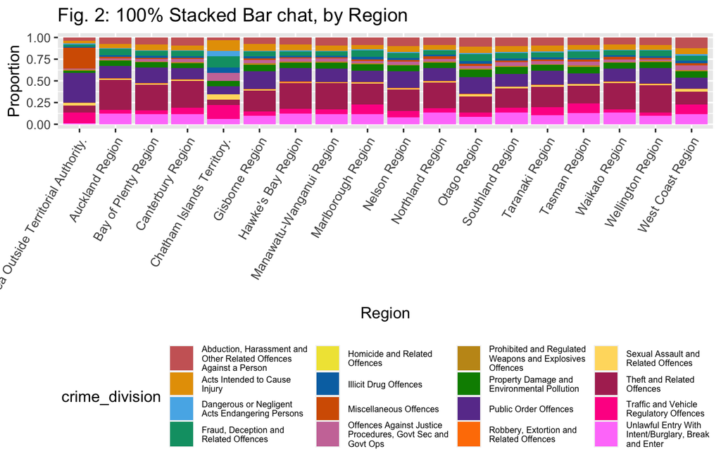

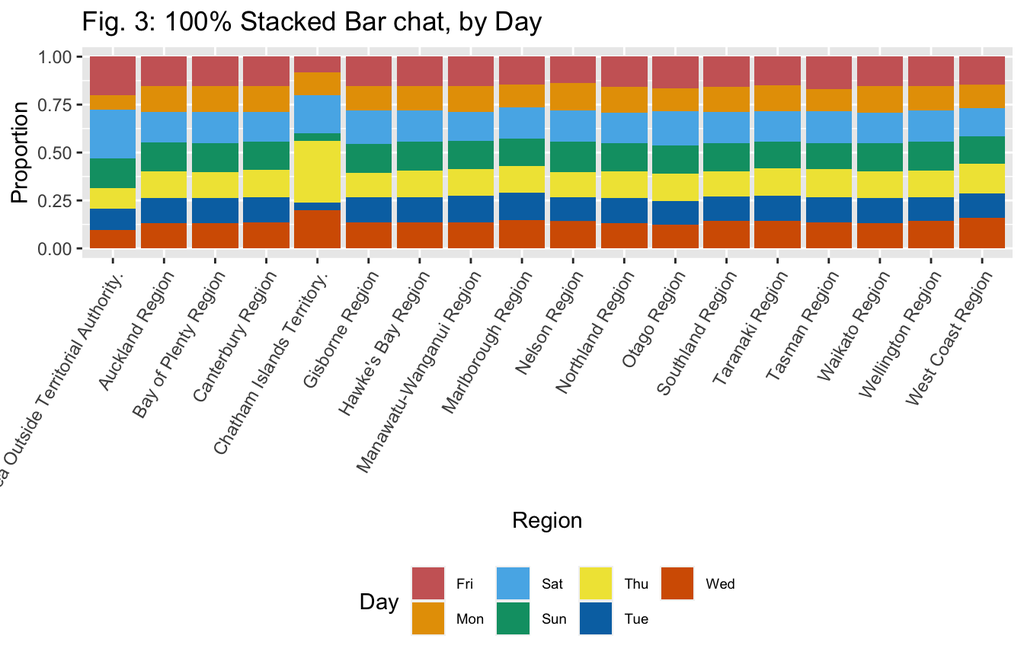

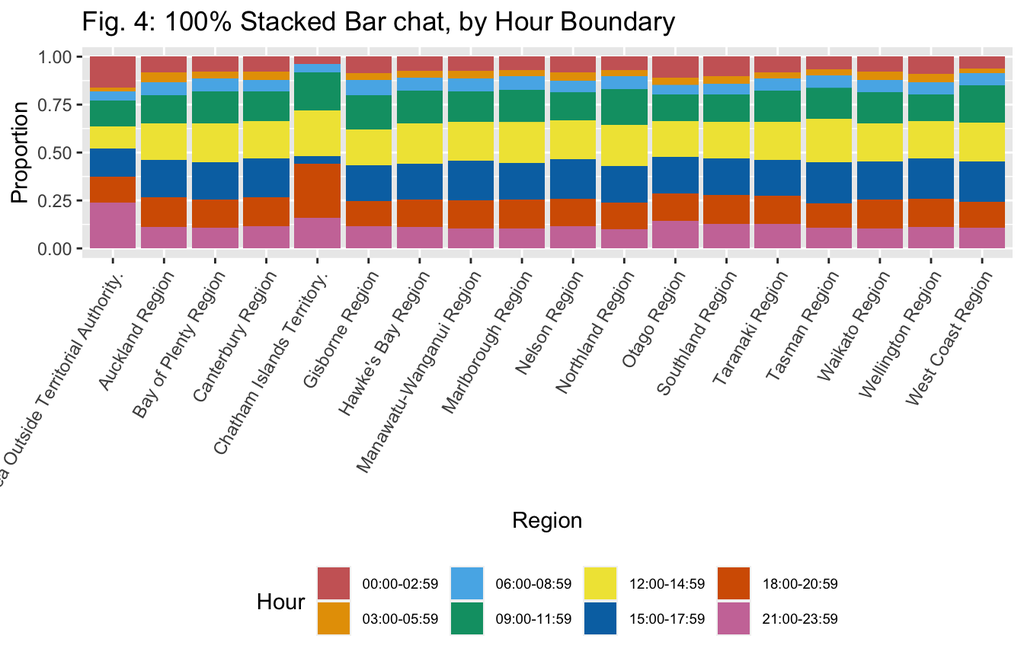

[figure not shown]

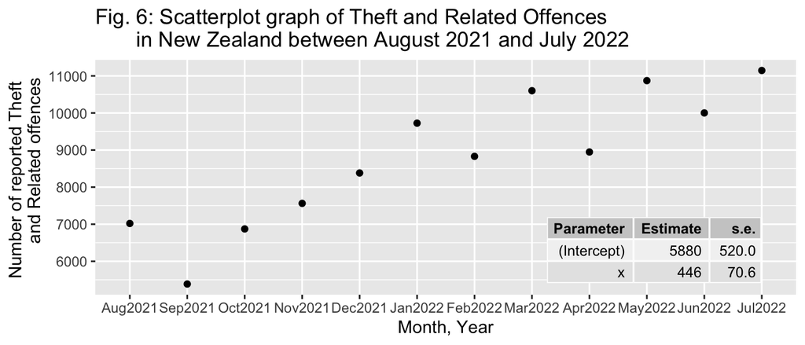

From the scatterplot of Theft and Related Offences in New Zealand between August 2021 and July 2022, we can observe a general trend of increasing number of reported Theft per month over the past year, suggesting the number of reported Thefts has increased. The difference between the total reported theft occurrences in August 2021 and July 2022 can also be calculated to be (11147 - 7020) = 4127, or an increase in reported theft occurrences by 4127, up 58.79% between August 2021 to July 2022.

Discussion

It is possible that some of the data reported during these months has been affected by extrinsic circumstances, namely the Auckland 2021 lockdown which occurred between August and December 2021. It is possible that due to this lockdown, fewer thefts were being committed (as more people were in their homes during this time) or reporting to police of crimes during this period lessened resulting in fewer reported crimes. Further investigations could be made here to include crime data over a longer period, for example over the past two or three years to gain a broader perspective of general crime trends in New Zealand. The study herein also does not consider a possible confounding factor of overall population change between in the period between August 2021 and July 2022. In further studies, it would be appropriate to consider statistical analyses on regional population data alongside crime statistics. To further investigate the causes of increased crime, it would be pertinent to analyse cost of living data, such as the consumer price index or food price index, so as to explore any possible relationship between these two factors. To conclude, the results of the statistical exploration taken on the New Zealand Police data of Demand and Activity show that, in general, the type of crime and when crimes are occurring in does not differ greatly between regions in New Zealand. However, when considering the overall crime trend in New Zealand between 2021 and 2022, an increase in crime occurrences is revealed.

References

Block, G. (2022, August 13). Crime victim rate hits record high, cops say numbers aren’t what they seem. NZ Herald. Retrieved September 25, 2022, from https://www.nzherald.co.nz/nz/crime-victim-rate-hits-record-high-but-cops-say-figures-arent-all-they-seem/K4T2YQWVOQOD4RXFKF3DTW445I/

CS&CPC (2005). The Root Causes of Crime CS&CPC Statement on the Root Causes of Crime approved in 1996. [online] Available at: http://preventingcrime.ca/wp-content/uploads/2014/08/Causes_of_Crime.pdf.

Ministry of Justice (2009). Theories of the Causes of Crime. [online] Available at: https://www.beehive.govt.nz/sites/default/files/Strategic_policy_brief_theories_on_the_causes_of_crime.pdf.

New Zealand Police. (n.d.). Demand and Activity. [online] Available at: https://www.police.govt.nz/about-us/statistics-and-publications/data-and-statistics/demand-and-activity.

Stats NZ (13 July 2022) Annual food price increase remains high at 6.6 percent: Stats NZ. Annual food price increase remains high at 6.6 percent | Stats NZ. Retrieved September 25, 2022, from https://www.stats.govt.nz/news/annual-food-price-increase-remains-high-at-6-6-percent/

Stats NZ (05 July 2022) New Zealanders’ mental wellbeing declines: Stats NZ. New Zealanders’ mental wellbeing declines | Stats NZ. Retrieved September 25, 2022, from https://www.stats.govt.nz/news/new-zealanders-mental-wellbeing-declines/

Vitz, E. (2022, July 19). How much has crime actually increased? The Spinoff. Retrieved September 25, 2022, from https://thespinoff.co.nz/society/19-07-2022/how-much-has-crime-really-increased

Appendix

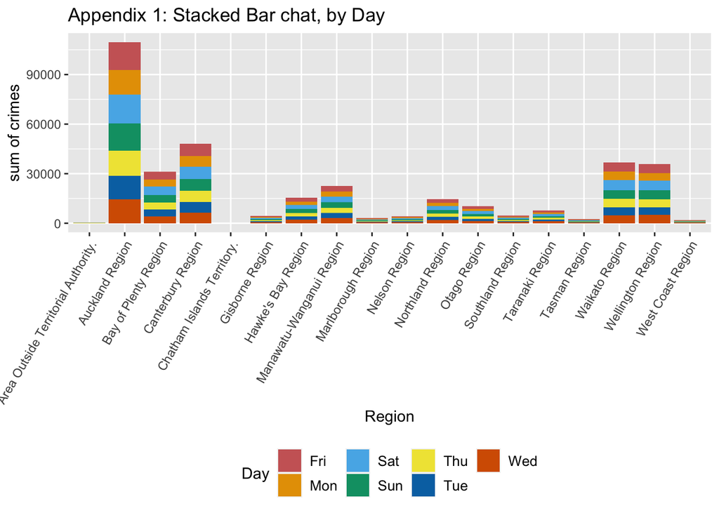

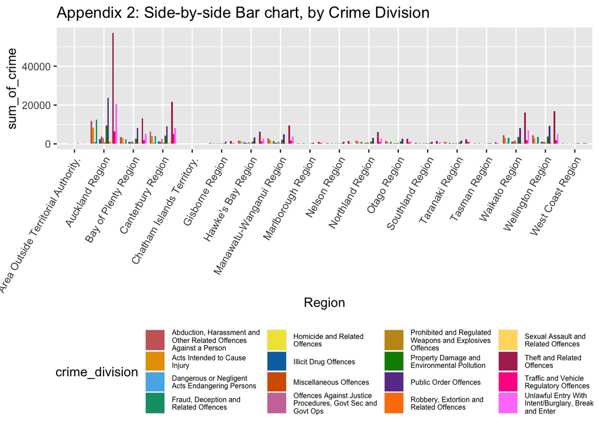

```r
#Appendix 1
#count_data_crime$log_of_sum<-log(count_data_crime$sum_of_crime)
Side_plot <- ggplot(data=count_data_crime, aes(x=Region, y=sum_of_crime, fill=crime_division)) +
  geom_bar(stat ='identity', position=position_dodge())+
  scale_fill_manual(values = c("#CC6666", "#E69F00", "#56B4E9", "#009E73", "#F0E442",
                               "#0072B2", "#D55E00", "#CC79A7","#C4961A",
                               "green4","#6A3D9A","#FF7F00",
                               "#FFDB6D","maroon","deeppink1", "orchid1"))+
  scale_x_discrete(guide = guide_axis(angle = 60)) +
  labs(title="Appendix 2: Side-by-side Bar chart, by Crime Division")+
  theme(legend.position = "bottom", legend.text = element_text(size = 6))


Side_plot
```

```r
#appendix 3: Table, showing the number of reported crimes occurring in each region for each day of the week.
table1 <- table(Hour_Day_Region$Day, Hour_Day_Region$Region)
table1
```

```
##
##       Area Outside Territorial Authority. Auckland Region Bay of Plenty Region
##   Fri                                  59           15887                 4504
##   Mon                                  24           13985                 3913
##   Sat                                  57           16315                 4844
##   Sun                                  45           15265                 4352
##   Thu                                  36           14659                 4017
##   Tue                                  38           13525                 3993
##   Wed                                  34           13728                 3927
##
##       Canterbury Region Chatham Islands Territory. Gisborne Region
##   Fri              6866                          2             632
##   Mon              5965                          3             528
##   Sat              7040                          5             716
##   Sun              6468                          1             615
##   Thu              6375                          8             540
##   Tue              5874                          1             555
##   Wed              6125                          5             557
##
##       Hawke's Bay Region Manawatu-Wanganui Region Marlborough Region
##   Fri               2249                     3251                423
##   Mon               1843                     2857                356
##   Sat               2355                     3242                474
##   Sun               2170                     3080                414
##   Thu               2002                     2912                417
##   Tue               1894                     2994                410
##   Wed               1957                     2894                426
##
##       Nelson Region Northland Region Otago Region Southland Region
##   Fri           562             2163         1589              706
##   Mon           547             1863         1205              585
##   Sat           639             2181         1736              735
##   Sun           602             1995         1452              642
##   Thu           511             1943         1395              593
##   Tue           497             1837         1199              575
##   Wed           564             1808         1216              644
##
##       Taranaki Region Tasman Region Waikato Region Wellington Region
##   Fri            1114           390           5146              5057
##   Mon             982           270           4644              4291
##   Sat            1183           386           5482              5272
##   Sun             990           315           4902              4936
##   Thu            1042           336           4699              4569
##   Tue             987           308           4532              4289
##   Wed            1058           313           4429              4659
##
##       West Coast Region
##   Fri               257
##   Mon               207
##   Sat               256
##   Sun               254
##   Thu               264
##   Tue               221
##   Wed               275
```

```r
#appendix 4: proportion table, showing the relative proportion of crimes occurring in each region for each day of the week.
round(prop.table(table1, 2), 3)
```

```
##
##       Area Outside Territorial Authority. Auckland Region Bay of Plenty Region
##   Fri                               0.201           0.154                0.152
##   Mon                               0.082           0.135                0.132
##   Sat                               0.195           0.158                0.164
##   Sun                               0.154           0.148                0.147
##   Thu                               0.123           0.142                0.136
##   Tue                               0.130           0.131                0.135
##   Wed                               0.116           0.133                0.133
##
##       Canterbury Region Chatham Islands Territory. Gisborne Region
##   Fri             0.154                      0.080           0.153
##   Mon             0.133                      0.120           0.127
##   Sat             0.157                      0.200           0.173
##   Sun             0.145                      0.040           0.148
##   Thu             0.143                      0.320           0.130
##   Tue             0.131                      0.040           0.134
##   Wed             0.137                      0.200           0.134
##
##       Hawke's Bay Region Manawatu-Wanganui Region Marlborough Region
##   Fri              0.155                    0.153              0.145
##   Mon              0.127                    0.135              0.122
##   Sat              0.163                    0.153              0.162
##   Sun              0.150                    0.145              0.142
##   Thu              0.138                    0.137              0.143
##   Tue              0.131                    0.141              0.140
##   Wed              0.135                    0.136              0.146
##
##       Nelson Region Northland Region Otago Region Southland Region
##   Fri         0.143            0.157        0.162            0.158
##   Mon         0.139            0.135        0.123            0.131
##   Sat         0.163            0.158        0.177            0.164
##   Sun         0.153            0.145        0.148            0.143
##   Thu         0.130            0.141        0.142            0.132
##   Tue         0.127            0.133        0.122            0.128
##   Wed         0.144            0.131        0.124            0.144
##
##       Taranaki Region Tasman Region Waikato Region Wellington Region
##   Fri           0.151         0.168          0.152             0.153
##   Mon           0.133         0.116          0.137             0.130
##   Sat           0.161         0.167          0.162             0.159
##   Sun           0.135         0.136          0.145             0.149
##   Thu           0.142         0.145          0.139             0.138
##   Tue           0.134         0.133          0.134             0.130
##   Wed           0.144         0.135          0.131             0.141
##
##       West Coast Region
##   Fri             0.148
##   Mon             0.119
##   Sat             0.148
##   Sun             0.146
##   Thu             0.152
##   Tue             0.127
##   Wed             0.159
```

```r
#appendix 5: Table, showing the number of reported crimes occurring in each region for hour boundary.
table2 <- table(Hour_Day_Region$Hour, Hour_Day_Region$Region)
table2
```

```
##
##               Area Outside Territorial Authority. Auckland Region
##   00:00-02:59                                  39            8425
##   03:00-05:59                                   7            5268
##   06:00-08:59                                  16            7227
##   09:00-11:59                                  46           15152
##   12:00-14:59                                  42           19887
##   15:00-17:59                                  47           19659
##   18:00-20:59                                  45           16219
##   21:00-23:59                                  51           11527
##
##               Bay of Plenty Region Canterbury Region Chatham Islands Territory.
##   00:00-02:59                 2318              3560                          1
##   03:00-05:59                  984              1986                          0
##   06:00-08:59                 2087              2887                          1
##   09:00-11:59                 4900              6732                          5
##   12:00-14:59                 5939              8591                          6
##   15:00-17:59                 5715              8890                          1
##   18:00-20:59                 4381              6848                          7
##   21:00-23:59                 3226              5219                          4
##
##               Gisborne Region Hawke's Bay Region Manawatu-Wanganui Region
##   00:00-02:59             344               1094                     1564
##   03:00-05:59             153                550                      912
##   06:00-08:59             335                971                     1431
##   09:00-11:59             744               2502                     3392
##   12:00-14:59             772               2924                     4185
##   15:00-17:59             770               2703                     4312
##   18:00-20:59             544               2074                     3222
##   21:00-23:59             481               1652                     2212
##
##               Marlborough Region Nelson Region Northland Region Otago Region
##   00:00-02:59                210           317              937         1066
##   03:00-05:59                 88           172              433          388
##   06:00-08:59                202           242              989          495
##   09:00-11:59                500           575             2558         1375
##   12:00-14:59                617           780             2924         1843
##   15:00-17:59                557           804             2637         1848
##   18:00-20:59                437           561             1919         1412
##   21:00-23:59                309           471             1393         1365
##
##               Southland Region Taranaki Region Tasman Region Waikato Region
##   00:00-02:59              445             583           156           2579
##   03:00-05:59              192             251            79           1441
##   06:00-08:59              251             468           149           2317
##   09:00-11:59              635            1164           372           5533
##   12:00-14:59              855            1452           523           6656
##   15:00-17:59              844            1394           490           6574
##   18:00-20:59              681            1109           305           5152
##   21:00-23:59              577             935           244           3582
##
##               Wellington Region West Coast Region
##   00:00-02:59              2824               108
##   03:00-05:59              1425                47
##   06:00-08:59              2084               105
##   09:00-11:59              4740               338
##   12:00-14:59              6476               348
##   15:00-17:59              6836               366
##   18:00-20:59              5028               235
##   21:00-23:59              3660               187
```

```r
#appendix 6: proportion table, showing the relative proportion of crimes occurring in each region for each hour boundary in any given day.
round(prop.table(table2,2),3)
```

```
##
##               Area Outside Territorial Authority. Auckland Region
##   00:00-02:59                               0.133           0.082
##   03:00-05:59                               0.024           0.051
##   06:00-08:59                               0.055           0.070
##   09:00-11:59                               0.157           0.147
##   12:00-14:59                               0.143           0.192
##   15:00-17:59                               0.160           0.190
##   18:00-20:59                               0.154           0.157
##   21:00-23:59                               0.174           0.112
##
##               Bay of Plenty Region Canterbury Region Chatham Islands Territory.
##   00:00-02:59                0.078             0.080                      0.040
##   03:00-05:59                0.033             0.044                      0.000
##   06:00-08:59                0.071             0.065                      0.040
##   09:00-11:59                0.166             0.151                      0.200
##   12:00-14:59                0.201             0.192                      0.240
##   15:00-17:59                0.193             0.199                      0.040
##   18:00-20:59                0.148             0.153                      0.280
##   21:00-23:59                0.109             0.117                      0.160
##
##               Gisborne Region Hawke's Bay Region Manawatu-Wanganui Region
##   00:00-02:59           0.083              0.076                    0.074
##   03:00-05:59           0.037              0.038                    0.043
##   06:00-08:59           0.081              0.067                    0.067
##   09:00-11:59           0.180              0.173                    0.160
##   12:00-14:59           0.186              0.202                    0.197
##   15:00-17:59           0.186              0.187                    0.203
##   18:00-20:59           0.131              0.143                    0.152
##   21:00-23:59           0.116              0.114                    0.104
##
##               Marlborough Region Nelson Region Northland Region Otago Region
##   00:00-02:59              0.072         0.081            0.068        0.109
##   03:00-05:59              0.030         0.044            0.031        0.040
##   06:00-08:59              0.069         0.062            0.072        0.051
##   09:00-11:59              0.171         0.147            0.185        0.140
##   12:00-14:59              0.211         0.199            0.212        0.188
##   15:00-17:59              0.191         0.205            0.191        0.189
##   18:00-20:59              0.150         0.143            0.139        0.144
##   21:00-23:59              0.106         0.120            0.101        0.139
##
##               Southland Region Taranaki Region Tasman Region Waikato Region
##   00:00-02:59            0.099           0.079         0.067          0.076
##   03:00-05:59            0.043           0.034         0.034          0.043
##   06:00-08:59            0.056           0.064         0.064          0.068
##   09:00-11:59            0.142           0.158         0.160          0.164
##   12:00-14:59            0.191           0.197         0.226          0.197
##   15:00-17:59            0.188           0.190         0.211          0.194
##   18:00-20:59            0.152           0.151         0.132          0.152
##   21:00-23:59            0.129           0.127         0.105          0.106
##
##               Wellington Region West Coast Region
##   00:00-02:59             0.085             0.062
##   03:00-05:59             0.043             0.027
##   06:00-08:59             0.063             0.061
##   09:00-11:59             0.143             0.195
##   12:00-14:59             0.196             0.201
##   15:00-17:59             0.207             0.211
##   18:00-20:59             0.152             0.136
##   21:00-23:59             0.111             0.108
```

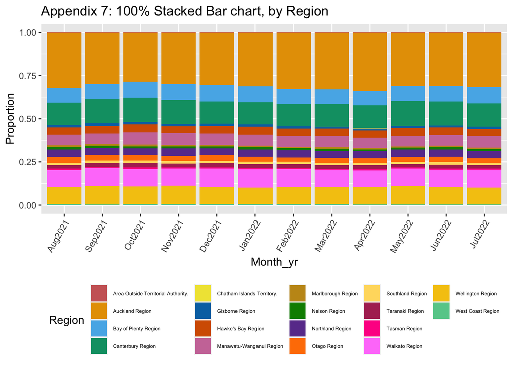

```r
#appendix 7:
Region_count <- Hour_Day_Region %>%
  group_by(Month_yr)%>%
  count(Region)
Region_count$Month_yr<- ordered(Region_count$Month_yr, levels<-c("Aug2021",
                                                                   "Sep2021",
                                                                   "Oct2021",
                                                                   "Nov2021",
                                                                   "Dec2021",
                                                                   "Jan2022",
                                                                   "Feb2022",
                                                                   "Mar2022",
                                                                   "Apr2022",
                                                                   "May2022",
                                                                   "Jun2022",
                                                                   "Jul2022"))


Region_count_plot<-ggplot(data = Region_count, aes(x=Month_yr, y=n, fill=Region)) +
  geom_col(stat ='identity', position='fill')+
  scale_x_discrete(guide = guide_axis(angle = 60)) +
  scale_fill_manual(values = c("#CC6666", "#E69F00", "#56B4E9", "#009E73", "#F0E442",
                               "#0072B2", "#D55E00", "#CC79A7","#C4961A",
                               "green4","#6A3D9A","#FF7F00",
                               "#FFDB6D","maroon","deeppink1", "orchid1", "9999CC", "#66CC99"))+
  labs(title="Appendix 7: 100% Stacked Bar chart, by Region", y='Proportion')+
  theme(legend.position = "bottom", legend.text = element_text(size = 5))
Region_count_plot
```

```r
#Appendix 8: proportion table, showing the relative proportion of crimes occurring in each region for each month (August 2021 - July 2022 inclusive.)
table3 <- table(Hour_Day_Region$Region, Hour_Day_Region$Month_yr)
round(prop.table(table3, 2),3)
```

```
##
##                                       Apr2022 Aug2021 Dec2021 Feb2022 Jan2022
##   Area Outside Territorial Authority.   0.001   0.001   0.001   0.001   0.001
##   Auckland Region                       0.338   0.321   0.304   0.326   0.311
##   Bay of Plenty Region                  0.083   0.084   0.095   0.089   0.091
##   Canterbury Region                     0.134   0.131   0.128   0.128   0.130
##   Chatham Islands Territory.            0.000   0.000   0.000   0.000   0.000
##   Gisborne Region                       0.012   0.013   0.013   0.014   0.013
##   Hawke's Bay Region                    0.041   0.042   0.045   0.043   0.045
##   Manawatu-Wanganui Region              0.061   0.063   0.066   0.062   0.064
##   Marlborough Region                    0.008   0.011   0.008   0.008   0.009
##   Nelson Region                         0.010   0.012   0.011   0.012   0.013
##   Northland Region                      0.041   0.044   0.041   0.042   0.043
##   Otago Region                          0.028   0.033   0.032   0.026   0.027
##   Southland Region                      0.012   0.013   0.015   0.012   0.014
##   Taranaki Region                       0.023   0.021   0.024   0.021   0.023
##   Tasman Region                         0.007   0.007   0.008   0.007   0.007
##   Waikato Region                        0.097   0.100   0.104   0.106   0.107
##   Wellington Region                     0.099   0.097   0.100   0.098   0.095
##   West Coast Region                     0.004   0.006   0.006   0.006   0.005
##
##                                       Jul2022 Jun2022 Mar2022 May2022 Nov2021
##   Area Outside Territorial Authority.   0.001   0.001   0.001   0.001   0.001
##   Auckland Region                       0.316   0.308   0.329   0.310   0.298
##   Bay of Plenty Region                  0.093   0.091   0.083   0.087   0.093
##   Canterbury Region                     0.135   0.139   0.134   0.143   0.139
##   Chatham Islands Territory.            0.000   0.000   0.000   0.000   0.000
##   Gisborne Region                       0.013   0.011   0.011   0.012   0.013
##   Hawke's Bay Region                    0.043   0.045   0.043   0.047   0.040
##   Manawatu-Wanganui Region              0.065   0.062   0.065   0.061   0.067
##   Marlborough Region                    0.009   0.009   0.009   0.007   0.011
##   Nelson Region                         0.012   0.012   0.013   0.012   0.011
##   Northland Region                      0.041   0.043   0.040   0.042   0.042
##   Otago Region                          0.028   0.031   0.028   0.029   0.031
##   Southland Region                      0.013   0.015   0.013   0.012   0.014
##   Taranaki Region                       0.020   0.021   0.022   0.020   0.023
##   Tasman Region                         0.006   0.008   0.006   0.007   0.006
##   Waikato Region                        0.105   0.100   0.101   0.100   0.099
##   Wellington Region                     0.097   0.100   0.097   0.106   0.105
##   West Coast Region                     0.004   0.004   0.006   0.004   0.006
##
##                                       Oct2021 Sep2021
##   Area Outside Territorial Authority.   0.001   0.001
##   Auckland Region                       0.285   0.299
##   Bay of Plenty Region                  0.093   0.086
##   Canterbury Region                     0.142   0.140
##   Chatham Islands Territory.            0.000   0.000
##   Gisborne Region                       0.013   0.014
##   Hawke's Bay Region                    0.045   0.045
##   Manawatu-Wanganui Region              0.071   0.063
##   Marlborough Region                    0.010   0.008
##   Nelson Region                         0.011   0.012
##   Northland Region                      0.041   0.040
##   Otago Region                          0.030   0.034
##   Southland Region                      0.015   0.014
##   Taranaki Region                       0.026   0.024
##   Tasman Region                         0.008   0.007
##   Waikato Region                        0.102   0.103
##   Wellington Region                     0.102   0.105
##   West Coast Region                     0.005   0.005
```